[figure not shown]

# Bill and flipper morphometrics in three *Pygoscelis* species

Working figures for the Sphen Lab peninsula morphology study

morphometrics

Pygoscelis

Palmer LTER

Working analysis of bill and flipper morphometrics across Adélie, Chinstrap, and Gentoo penguins sampled at Palmer Station, prepared for the appendix of the Sphen Lab renewal proposal.

Author

Affiliation

A. Rueda

Postdoctoral Researcher, Sphen Lab, Department of Integrative Biology, UW-Madison

Published

July 21, 2026

Modified

October 9, 2026

## 1 Overview

I joined the Sphen Lab a few weeks ago, and this is my first real task: Maris asked for one figure for the renewal appendix: bill length against bill depth, colored by species. That is the first plot below, and it took about five minutes.

The rest of this document exists because, from what the rest of the lab tells me, the last three “quick figures” all came back a month later needing a rerun against updated data. Writing it this way costs perhaps an extra twenty minutes now; regenerating it in October costs one command. The measurements are bill length, bill depth, flipper length, and body mass, which the lab has been collecting at Palmer Station across recent field seasons for the three *Pygoscelis* species breeding on and around Anvers Island: Adélie (*P. adeliae*), Chinstrap (*P. antarcticus*), and Gentoo (*P. papua*).

The document proceeds in four stages:

1. Load the observations and check what came through
2. Produce the bill morphometrics figure for the appendix
3. Summarize flipper length by species
4. Fit a small model relating flipper length to body mass

Stages 3 and 4 were not requested. They are here because the same data was already loaded and the comparison is one Maris will almost certainly ask for next.

Every figure, table, and fitted model is written to `output/` as a file, not only displayed inline. Figures go under `output/figures/` and tables under `output/tables/`, following the project’s own folder layout. The appendix needs image files it can drop into the proposal document, and a job running on a cluster has nowhere to display anything, so in both cases the artifact on disk is the actual deliverable. Each file is saved through `toolero::save_output()`, which also notes what was saved, how, and whether it worked, so the document finishes with a record of its own outputs rather than a list I maintain by hand.

## 2 Input and output resolution

This section is infrastructure rather than analysis. It exists so the document runs unmodified in three places: interactively while I am working on it, rendered through Quarto with a path supplied via `params`, and executed as an `Rscript` on a CHTC node with the path passed as a command-line argument. `resolve_input_path()` works out which of the three applies and returns the path that context should use. Only the interactive path is spelled out below. Under Quarto it falls back to `params$input_file`. Both are written from the project root (`data-raw/...`), and `resolve_input_path()` reads them from there, so the same spelling works whether Quarto runs this document from `reports/` or I run its chunks one at a time. Under `Rscript` it falls back to the first command-line argument, taken as given. Either way it checks that the file exists before anything tries to read it.

The one thing that has to *behave* differently by context, rather than just find a file, is on-screen output: there is nothing to display under `Rscript`, so tables and plots are only printed when this is not a batch run. `detect_execution_context()` answers that question on its own.

Output paths follow the same rule: they start at the project root, as in `"output/figures/bill-morphometrics.png"`, and `save_output()` reads them from there. A render from `reports/` therefore still writes to the project’s `output/` rather than to a stray `reports/output/`, and I do not need `here::here()` anywhere in the document. On a CHTC node there is no project root to find, so `toolero` uses the job’s scratch directory in its place, which is exactly where HTCondor looks for files to send back on completion. One spelling, correct in all three contexts, without special-casing.

`save_plot()` below exists only because `ggsave()` takes the file name first and the plot second, the reverse of the order `save_output()` passes them in. Giving the wrapper a name, rather than writing it inline, also means the record says `save_plot` rather than an anonymous function.

```r
input_file <- resolve_input_path(
  interactive = "data-raw/palmer-morphometrics-2024.csv"
)

context <- detect_execution_context()
should_render_outputs <- !identical(context, "rscript")

# save_output() creates any missing folder, so none are created here.
save_plot <- function(object, file_path, ...) {
  ggplot2::ggsave(filename = file_path, plot = object, ...)
}
```

## 3 Load data

The observations are read from the resolved path and stored as `penguins`, with the same `read_csv()` call the first figure used. The message that follows reports the row and column counts and how many columns contain missing values, and I read it rather than skipping it. Field measurements arrive with gaps, and it matters whether a missing bill depth is one bird or forty.

```r
penguins <- read_csv(input_file, show_col_types = FALSE)

n_missing_cols <- sum(colSums(is.na(penguins)) > 0)
message(
  "Read ", nrow(penguins), " rows and ", ncol(penguins), " columns; ",
  n_missing_cols, " columns contain missing values."
)
```

```
Read 344 rows and 8 columns; 5 columns contain missing values.
```

## 4 Bill morphometrics

This is the figure for the appendix.

Saved at 300 dpi, which is what the proposal template wants for print.

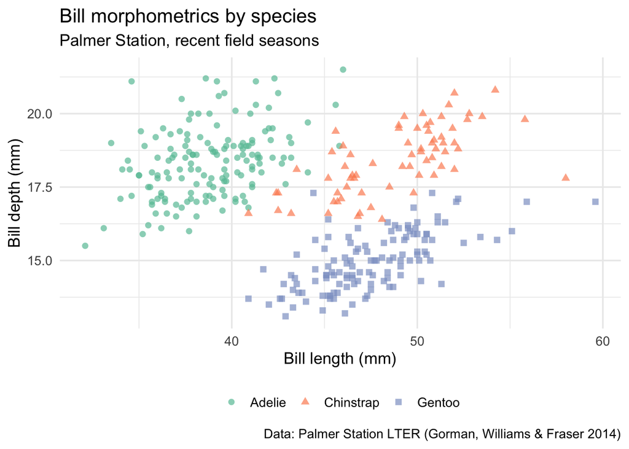

Figure 1: Bill length against bill depth, by species

```r
bill_plot <- penguins |>
  ggplot(aes(
    x = bill_length_mm,
    y = bill_depth_mm,
    color = species,
    shape = species
  )) +
  geom_point(alpha = 0.7, size = 2) +
  scale_color_brewer(palette = "Set2") +
  labs(
    title    = "Bill morphometrics by species",
    subtitle = "Palmer Station, recent field seasons",
    x        = "Bill length (mm)",
    y        = "Bill depth (mm)",
    color    = NULL,
    shape    = NULL,
    caption  = "Data: Palmer Station LTER (Gorman, Williams & Fraser 2014)"
  ) +
  theme_minimal(base_size = 13) +
  theme(legend.position = "bottom")

save_output(
  bill_plot,
  "output/figures/bill-morphometrics.png",
  .f     = save_plot,
  width  = 7,
  height = 5,
  dpi    = 300,
  note   = "The appendix figure"
)

if (should_render_outputs) bill_plot
```

One thing needs raising before this goes in the appendix. Pooled across all three species, bill length and bill depth are *negatively* associated, so longer bills look shallower. Within each species taken separately, the association is *positive*: longer-billed birds also have deeper bills, as one would expect. The pooled trend is an artifact of Gentoos being both long-billed and shallow-billed relative to the other two, not a biological relationship.

This is a textbook case of Simpson’s paradox, and it is exactly why the species coloring is doing real work here rather than decorating the plot. An uncolored version of this same figure would support the opposite conclusion. A sentence in the caption would spare a reviewer from reconstructing it.

## 5 Flipper length by species

Not requested, but the data was loaded.

The observations are grouped by species and four descriptive statistics calculated for flipper length: minimum, maximum, mean, and standard deviation. Missing flipper measurements are excluded from each calculation. The minimum and maximum give the observed range within each species; the mean estimates typical flipper length; the standard deviation describes spread around it.

The summary is written out as CSV rather than only as a formatted table. The CSV is the reusable artifact, since it can be read back, joined against, or reformatted, where a rendered table is only a presentation of it.

```r
flipper_stats <- penguins |>
  group_by(species) |>
  summarize(
    min_flipper_length  = min(flipper_length_mm, na.rm = TRUE),
    max_flipper_length  = max(flipper_length_mm, na.rm = TRUE),
    mean_flipper_length = mean(flipper_length_mm, na.rm = TRUE),
    sd_flipper_length   = sd(flipper_length_mm, na.rm = TRUE),
    .groups = "drop"
  )

save_output(
  flipper_stats,
  "output/tables/flipper-stats.csv",
  .f   = write_csv,
  note = "Flipper summary statistics"
)
```

Table 1 presents these in millimeters, rounded to whole units for display.

```r
flipper_stats_tbl <- flipper_stats |>
  gt() |>
  fmt_number(decimals = 0) |>
  cols_label(
    species              = "Species",
    min_flipper_length   = "Minimum",
    max_flipper_length   = "Maximum",
    mean_flipper_length  = "Mean",
    sd_flipper_length    = "SD"
  ) |>
  tab_header(
    title = "Flipper length by species",
    subtitle = "Summary statistics in millimeters"
  )

if (should_render_outputs) flipper_stats_tbl
```

Table 1: Flipper statistics per species

Flipper length by species

Summary statistics in millimeters

| Species | Minimum | Maximum | Mean | SD |
| --- | --- | --- | --- | --- |
| Adelie | 172 | 210 | 190 | 7 |
| Chinstrap | 178 | 212 | 196 | 7 |
| Gentoo | 203 | 231 | 217 | 6 |

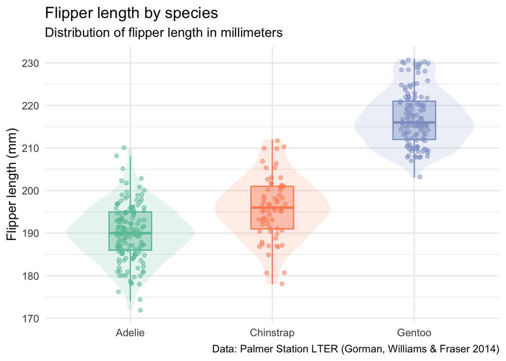

Figure 2: Flipper length distribution by species

```r
flipper_plot <- penguins |>
  ggplot(aes(
    x = species,
    y = flipper_length_mm,
    color = species,
    fill = species
  )) +
  geom_violin(alpha = 0.15, linewidth = 0) +
  geom_boxplot(alpha = 0.4, width = 0.3, outlier.shape = NA) +
  geom_jitter(width = 0.1, alpha = 0.5, size = 1.5) +
  scale_color_brewer(palette = "Set2") +
  scale_fill_brewer(palette = "Set2") +
  labs(
    title    = "Flipper length by species",
    subtitle = "Distribution of flipper length in millimeters",
    x        = NULL,
    y        = "Flipper length (mm)",
    caption  = "Data: Palmer Station LTER (Gorman, Williams & Fraser 2014)"
  ) +
  theme_minimal(base_size = 13) +
  theme(legend.position = "none")

save_output(
  flipper_plot,
  "output/figures/flipper-length-dist.png",
  .f     = save_plot,
  width  = 7,
  height = 5,
  dpi    = 300,
  note   = "Flipper length distributions by species"
)

if (should_render_outputs) flipper_plot
```

## 6 Flipper length and body mass

Penguins with longer flippers tend to be heavier, which is unsurprising and well established. A simple linear regression recovers it directly. The point of fitting it here is not the result but the structure: it introduces a second kind of input to the pipeline, a modeling choice, alongside the data itself.

`species_role` controls how species enters the model. It can be left out, added as an additive term giving each species its own intercept, or included as an interaction giving each species its own slope. Changing it does not touch the data; it changes only how the model reads it.

There is one case where the choice is made for me. When this runs once per species on the cluster, each job sees a single species, and a species term with only one level cannot be estimated, so the model falls back to flipper length alone. The per-species slopes the interaction would have estimated come out of the three jobs separately instead.

The fitted model is saved as an `.rds`. A model object is an analysis result in the same sense a figure is. Saving it means a later question about predictions or diagnostics does not require refitting, and means the exact object behind the reported coefficients is recoverable.

````markdown
```{r}
#| label: fit-model

# species_role controls how species enters the model:
#   "none"        : flipper length only
#   "additive"    : flipper length + species (parallel intercepts)
#   "interaction" : flipper length * species (separate slopes)

species_role <- "interaction"

# A per-species subset has a single level of species, and lm() cannot
# estimate a term with one level, so fall back to flipper length alone.
if (n_distinct(penguins$species) < 2) {
  species_role <- "none"
}

model_formula <- switch(species_role,
  none        = body_mass_g ~ flipper_length_mm,
  additive    = body_mass_g ~ flipper_length_mm + species,
  interaction = body_mass_g ~ flipper_length_mm * species
)

flipper_model <- lm(model_formula, data = penguins)

save_output(
  flipper_model,
  "output/flipper-model.rds",
  .f   = saveRDS,
  note = paste("The fitted model object; species role:", species_role)
)
```
````

Table 2 gives the fitted coefficients. Under the interaction setting each species is allowed its own relationship between flipper length and body mass rather than sharing a single slope.

```r
model_coefficients <- broom::tidy(flipper_model)

save_output(
  model_coefficients,
  "output/tables/model-coefficients.csv",
  .f   = write_csv,
  note = "Model coefficient estimates"
)

model_tbl <- model_coefficients |>
  gt() |>
  fmt_number(columns = c(estimate, std.error, statistic), decimals = 2) |>
  fmt_scientific(columns = p.value, decimals = 2) |>
  cols_label(
    term      = "Term",
    estimate  = "Estimate",
    std.error = "Std. Error",
    statistic = "t statistic",
    p.value   = "p value"
  ) |>
  tab_header(
    title = "Body mass by flipper length",
    subtitle = paste("Species role:", species_role)
  )

if (should_render_outputs) model_tbl
```

Table 2: Estimated coefficients, body mass by flipper length

Body mass by flipper length

Species role: interaction

| Term | Estimate | Std. Error | t statistic | p value |
| --- | --- | --- | --- | --- |
| (Intercept) | −2,535.84 | 879.47 | −2.88 | 4.19 × 10<sup>−3</sup> |
| flipper_length_mm | 32.83 | 4.63 | 7.10 | 7.69 × 10<sup>−12</sup> |
| speciesChinstrap | −501.36 | 1,523.46 | −0.33 | 7.42 × 10<sup>−1</sup> |
| speciesGentoo | −4,251.44 | 1,427.33 | −2.98 | 3.11 × 10<sup>−3</sup> |
| flipper_length_mm:speciesChinstrap | 1.74 | 7.86 | 0.22 | 8.25 × 10<sup>−1</sup> |
| flipper_length_mm:speciesGentoo | 21.79 | 6.94 | 3.14 | 1.84 × 10<sup>−3</sup> |

Figure 3 shows those fits against the observed points, making the difference in slopes visible directly.

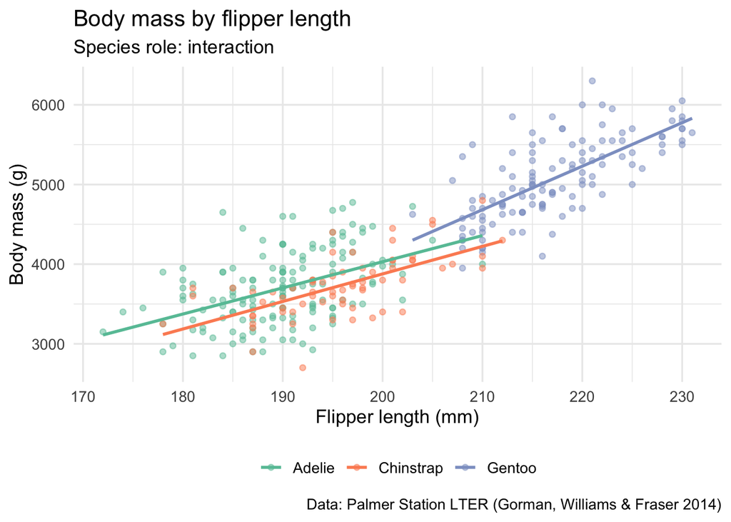

Figure 3: Fitted relationship between flipper length and body mass

```r
model_plot <- penguins |>
  ggplot(aes(x = flipper_length_mm, y = body_mass_g, color = species)) +
  geom_point(alpha = 0.5, size = 1.5) +
  geom_smooth(method = "lm", se = FALSE, linewidth = 1) +
  scale_color_brewer(palette = "Set2") +
  labs(
    title    = "Body mass by flipper length",
    subtitle = paste("Species role:", species_role),
    x        = "Flipper length (mm)",
    y        = "Body mass (g)",
    color    = NULL,
    caption  = "Data: Palmer Station LTER (Gorman, Williams & Fraser 2014)"
  ) +
  theme_minimal(base_size = 13) +
  theme(legend.position = "bottom")

save_output(
  model_plot,
  "output/figures/model-fit.png",
  .f     = save_plot,
  width  = 7,
  height = 5,
  dpi    = 300,
  note   = "Fitted body mass against flipper length"
)

if (should_render_outputs) model_plot
```

## 7 What this produced

Every `save_output()` call above added a line to `output/accumulator.csv`. The last step collapses those lines into the *output record*, `output/project-manifest.json`: one entry per file, with how it was written, whether the write succeeded, the note I gave it, and the git commit this document was run from. It overwrites the previous record, since every render produces a fresh one.

```r
generate_manifest(overwrite = TRUE)
```

Table 3 is that record, read back.

```r
if (should_render_outputs) {
  read_output_records() |>
    select(file_path, function_used, status, note) |>
    gt() |>
    cols_label(
      file_path     = "File",
      function_used = "Written with",
      status        = "Status",
      note          = "What it is"
    )
}
```

Table 3: What this document produced, from its output record

| File | Written with | Status | What it is |
| --- | --- | --- | --- |
| output/figures/bill-morphometrics.png | save_plot | success | The appendix figure |
| output/tables/flipper-stats.csv | write_csv | success | Flipper summary statistics |
| output/figures/flipper-length-dist.png | save_plot | success | Flipper length distributions by species |
| output/flipper-model.rds | saveRDS | success | The fitted model object; species role: interaction |
| output/tables/model-coefficients.csv | write_csv | success | Model coefficient estimates |
| output/figures/model-fit.png | save_plot | success | Fitted body mass against flipper length |

## 8 Where this ran

I will not always be the one running this document, so it also reports where it ran. Table 4 is the same table on my laptop, inside a container, and on a cluster node, and only the values change. It appears when the document renders, since a batch run has nowhere to show it.

```r
if (should_render_outputs) {
  tibble(
    item  = c("Execution context", "Operating system", "R version", "Run at"),
    value = c(
      context,
      paste(Sys.info()[["sysname"]], Sys.info()[["release"]]),
      R.version.string,
      format(Sys.time(), "%Y-%m-%d %H:%M %Z")
    )
  ) |>
    gt() |>
    tab_options(column_labels.hidden = TRUE)
}
```

Table 4: Where this document ran

| Execution context | quarto |
| --- | --- |
| Operating system | Darwin 25.6.0 |
| R version | R version 4.6.1 (2026-06-24) |
| Run at | 2026-10-09 13:17 CDT |

## 9 Notes for Maris

The appendix figure is `output/figures/bill-morphometrics.png`, at 300 dpi. My suggestion is to keep the species coloring described in the caption text as well as shown in the plot, for the Simpson’s paradox reason above, since a reviewer skimming an uncolored reproduction would draw the wrong conclusion.

Everything else this produced is under `output/`, and Table 3 lists it, written by the document itself rather than by me.

Everything regenerates from `data-raw/palmer-morphometrics-2024.csv` with one render. If the season’s measurements land before submission, drop the updated file into `data-raw/`, point `params$input_file` at it, and rerun. No edits to the analysis itself are required.

## 10 Next steps

This document currently assumes a lot: that I have R and every package it needs installed correctly, that I am running it on my own laptop, and that “rerun it” means “I personally sit down and click render.” None of that holds once this analysis needs to run somewhere I am not, which, given the scale Maris eventually wants for the full peninsula dataset, it will.

Two things close that gap, and neither touches this document’s logic. Containerizing the project packages the R version, every package, the system libraries underneath them, and the raw measurements into an image that runs identically on my laptop and on a machine I have never logged into, so “it worked when I rendered it” stops being a claim about my machine specifically. The script itself stays out of the image and travels with each job, so an edit here means re-sending one file, not rebuilding anything. Once that image exists, submitting it to CHTC’s high-throughput cluster is what actually removes me from the loop: the job runs, the results come back, and I did not need to keep my laptop open or awake for any of it. The output record comes back with them, so “did every job write everything it should have” is a question with a table for an answer rather than a folder to inspect by eye.

That second step is also where splitting the data starts to matter. Nothing here needs per-species files; a scatterplot and a grouped summary work fine against the whole dataset. A cluster job submitted once per species does need them, and `write_by_group()` will write them into `data/jobs/`, the project’s standard place for split data, along with a manifest that enumerates exactly which files exist and where. The same document then runs once per file, unchanged. The split will feel like unnecessary setup work right up until it is not.

Research Cyberinfrastructure · Division of Information Technology · UW–Madison